# HW22

Ray Nelson

8 Apr 2019

## Concepts

Explain the idea of themes within ggplot.

Themes allow us to customize the non-data elements of our plot. There are default themes that change many of the aspects of a plot with a single statement. You can also change individual elements such as tick marks, background colors, legend position, etc.

## Interpretation of code

Interpret the following R code chunks:

Code Chunk #1 Zooming using coord_cartesian

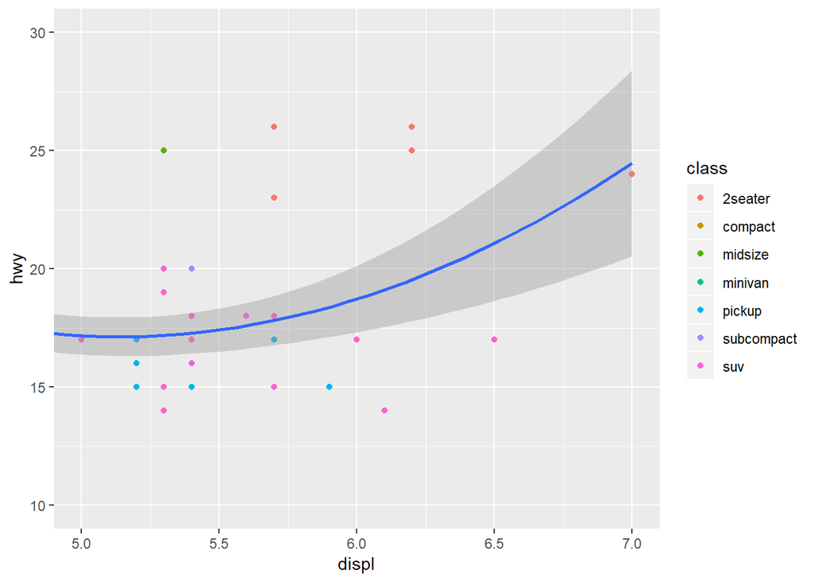

```r
mpg %>%
  ggplot(aes(displ, hwy)) +
  geom_point(aes(color = class)) +
  geom_smooth() +
  coord_cartesian(xlim = c(5, 7), ylim = c(10, 30))
```

Line 1 - 4: Create the regular scatterplot with a loess smoothed line. The points are colored by the class of the car.

Line 5: Plots all of the points but limits the graph to those cars with displacement between 5 and 7 and highway mileage between 10 and 30. All of the points are still considered in the plot but we only see those specified by the limits in coord_cartesian.

Code Chunk #2 Zooming using filtering

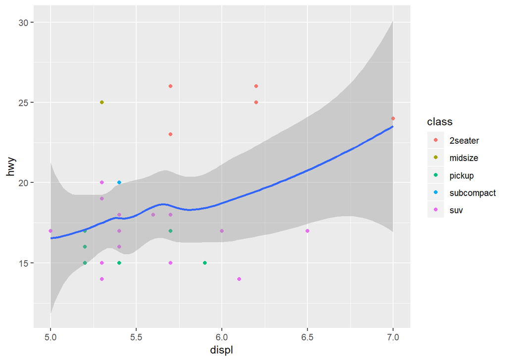

```r
mpg %>%
  filter(displ >= 5, displ <= 7, hwy >= 10, hwy <= 30) %>%
  ggplot(aes(displ, hwy)) +
  geom_point(aes(color = class)) +
  geom_smooth()
```

Lines 1 - 2: Limits the data to be plotted to only those observations with displacement between 5 and 7 and highway mileage between 10 and 30.

Lines 3 - 5: Create the regular scatterplot with a loess smooth.

Why are the loess lines in these two graphs different?

The smoothed line in the first graph is using all of the data whereas the second using only 38 rows from mpg that satisfy the filtering condition.

## Write Code

Problem 3 from 28.2.1 Exercises

Take an exploratory graphic that you’ve created during the semester, and add informative labels, annotations, scales, and themes to make it easier for others to understand.

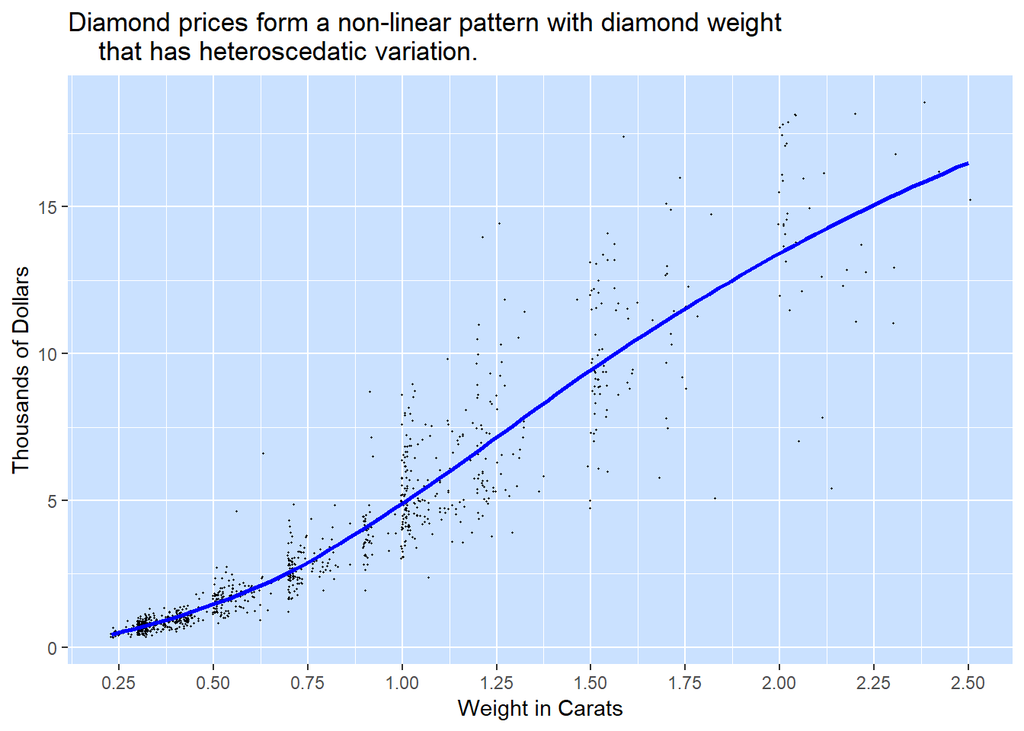

```r
diamonds %>%
  sample_n(1000) %>%
  filter(carat <= 2.5) %>%
  ggplot(aes(carat, price / 1000)) +
  geom_point(size = 0.5, shape = 20, position = "jitter") +
  geom_smooth(colour = "blue", se = FALSE) +
  labs(
    title = "Diamond prices form a non-linear pattern with diamond weight
    that has heteroscedatic variation.",
    y = "Thousands of Dollars",
    x = "Weight in Carats"
  ) +
  scale_x_continuous(breaks = seq(0, 2.5, 0.25)) +
  theme(panel.background = element_rect(fill = "lightsteelblue1"))
```